### Cargamos dataset

```python
import pandas as pd
```

```python
filename= 'tweets-sentiment-worldcup.csv'
df = pd.read_csv(filename, engine = 'python')#encoding='ISO-8859-1')
```

# EDA (Exploratory Data Analysis)

En primer lugar, muestreamos 15 ejemplos aleatorios para ver la estructura general de nuestro dataset

```python
df.sample(15)
```

|  | tweet_date_created | tweet_id | tweet_text | language | sentiment | sentiment_score |
| --- | --- | --- | --- | --- | --- | --- |
| 803719 | 2018-07-11T10:08:47.840000 | 1016987658277539840 | Yeah, we can't concentrate either. So here's a... | en | NEUTRAL | {"Neutral":0.993862628936767578125,"Negative":... |
| 489279 | 2018-07-11T17:00:33.816000 | 1017091282865442816 | Is it coming home? Is it actually coming home?... | en | NEUTRAL | {"Neutral":0.979445993900299072265625,"Negativ... |
| 771066 | 2018-06-27T13:43:32.312000 | 1011968275096461312 | @HKane Good luck for tomorrow you are all doin... | en | POSITIVE | {"Neutral":0.0252998955547809600830078125,"Neg... |
| 206118 | 2018-07-07T19:10:23.911000 | 1015674406809595911 | #ThreeLions thoughts: Everton have a gem of a ... | en | NEUTRAL | {"Neutral":0.785395085811614990234375,"Negativ... |
| 698190 | 2018-06-24T17:47:33 | 1010942517427228672 | @JesseLingard @England @FIFAWorldCup My niece ... | en | NEUTRAL | {"Neutral":0.782051146030426025390625,"Negativ... |
| 923164 | 2018-07-11T22:14:49.513000 | 1017170371706048513 | How people can say that the English aren’t the... | en | NEUTRAL | {"Neutral":0.92442524433135986328125,"Negative... |
| 650205 | 2018-07-11T10:13:21.712000 | 1016988807575539712 | @HKane will do it for\n#ThreeLions #MatchDay \... | en | NEUTRAL | {"Neutral":0.917717039585113525390625,"Negativ... |
| 86572 | 2018-06-17T12:47:45 | 1008330355705827328 | Going right from church to catch the second ha... | en | NEUTRAL | {"Neutral":0.60275828838348388671875,"Negative... |
| 105693 | 2018-05-26T17:25:34 | 1000427738451333120 | @England @FIFAWorldCup @England does anyone ha... | en | NEUTRAL | {"Neutral":0.95742547512054443359375,"Negative... |
| 406855 | 2018-06-24T10:57:05.553000 | 1010839223388311553 | @walshie247 Hi! You can get 25/1 for #ENG to b... | en | NEUTRAL | {"Neutral":0.863880217075347900390625,"Negativ... |
| 194467 | 2018-06-16T19:48:00 | 1008073727630770178 | @BashirAhmaad @Apoceleb @NGSuperEagles @MBuhar... | en | NEUTRAL | {"Neutral":0.99841487407684326171875,"Negative... |
| 823583 | 2018-07-11T20:47:27.193000 | 1017148385114120193 | @GunnnFC @jackcun44253414 @WhiteSun_Spurs @Eng... | en | NEUTRAL | {"Neutral":0.778083622455596923828125,"Negativ... |
| 222427 | 2018-06-18T17:33:02 | 1008764538718769153 | C'mon @HKane, score some goals tonight!???? #E... | en | NEUTRAL | {"Neutral":0.877771794795989990234375,"Negativ... |
| 67114 | 2018-07-11T22:38:00.608000 | 1017176207794884608 | @itvfootball @England @trippier2 @gabrielclark... | en | NEUTRAL | {"Neutral":0.974730193614959716796875,"Negativ... |
| 98993 | 2018-06-26T17:28:10.032000 | 1011662415631532032 | Eagerly waiting for Argentina to win and Icela... | en | NEUTRAL | {"Neutral":0.7446956634521484375,"Negative":0.... |

Visualizamos también información de carácter general como el tipo de elemento o el número de entradas

```python
df.info()
```

```
<class 'pandas.core.frame.DataFrame'>
RangeIndex: 943169 entries, 0 to 943168
Data columns (total 6 columns):
 #   Column              Non-Null Count   Dtype
---  ------              --------------   -----
 0   tweet_date_created  943169 non-null  object
 1   tweet_id            943169 non-null  int64
 2   tweet_text          943169 non-null  object
 3   language            943169 non-null  object
 4   sentiment           943169 non-null  object
 5   sentiment_score     943169 non-null  object
dtypes: int64(1), object(5)
memory usage: 43.2+ MB
```

### Sentimiento

Podemos observar que hay 4 posibilidades en su campo más general (**sentiment**):

```python
df.sentiment.unique()
```

```
array(['NEUTRAL', 'POSITIVE', 'NEGATIVE', 'MIXED'], dtype=object)
```

Así como sus porcentajes de aparición, y por tanto el balanceo entre clases:

```python
df.sentiment.value_counts()
```

```
NEUTRAL     667025
POSITIVE    227357
NEGATIVE     42133
MIXED         6654
Name: sentiment, dtype: int64
```

```python
df.sentiment.value_counts(normalize=True)
```

```
NEUTRAL     0.707217
POSITIVE    0.241056
NEGATIVE    0.044672
MIXED       0.007055
Name: sentiment, dtype: float64
```

```python
df.sentiment.describe()
```

```
count      943169
unique          4
top       NEUTRAL
freq       667025
Name: sentiment, dtype: object
```

Y la estructura del campo **sentiment_score**, la cual nos aporta valores interesantes pero que inicialmente no serán utilizados para nuestras primeras pruebas por simplicidad.

```python
df.sentiment_score[0]
```

```
'{"Neutral":0.991141796112060546875,"Negative":0.0045408555306494235992431640625,"Positive":0.00343008153140544891357421875,"Mixed":0.0008872128673829138278961181640625}'
```

### Fechas de publicación

```python
df['tweet_date_created'].min()
```

```
'2018-05-05T01:25:48'
```

```python
df['tweet_date_created'].max()
```

```
'2018-07-15T14:59:59.961000'
```

### Valores

Comprobamos también, que no hay ningún **valor nulo** en el dataset

```python
df.isna().sum()
```

```
tweet_date_created    0
tweet_id              0
tweet_text            0
language              0
sentiment             0
sentiment_score       0
dtype: int64
```

```python
df.isnull().sum()
```

```
tweet_date_created    0
tweet_id              0
tweet_text            0
language              0
sentiment             0
sentiment_score       0
dtype: int64
```

Así como posibles **valores repetidos**:

```python
len(set(df.tweet_text))
```

```
860931
```

Dado que en nuestro dataset tenemos 943169 entradas (filas) y solo 860931 son únicas en función de su texto, existe un número considerable de valores repetidos.

Por último, antes de comenzar con el preprocesamiento, realizamos una copia del DataFrame (data) donde iremos almacenando el conjunto de datos con los que trabajar

```python
data = df.copy()
```

# Preprocesado

```python
import re
import nltk
```

```python
from tqdm import tqdm
tqdm.pandas()
```

```python
import preprocessor as p #pip install tweet-preprocessor
import string
```

### Función de preparación del texto

Utilizando las librerías importadas unas líneas más arriba, a continuación se decalara una función encargada de realizar un primer preprocesamiento o limpieza del texto de nuestros tweets.

Destacar que a parte de las labores típicas de limpieza en este tipo de procesos como la transformación a minúsculas o la eliminación de caracteres especiales, se ha realizado un tratamiento que reemplaza tanto las URLs como las menciones por una palabra genérica.

En el caso de los Hastags he creído oportuno mantener su contenido ya que puede ser interesante para el análisis del sentimiento.

```python
p.set_options(p.OPT.URL, p.OPT.MENTION)#, p.OPT.HASHTAG)

def clean_text(text):
    try:
        text = text.lower()
        text = re.sub(r"\[(.*?)\]", "", text)
        text = p.tokenize(text)

        #remove tags
        text=re.sub("&lt;/?.*?&gt;"," &lt;&gt; ",text)
        text = re.sub('[^\'\’#a-zA-Z]', ' ', text)
        text = re.sub(r"\s+", " ", text)
        return text

    except Exception:
        print("Error:\n", text)
```

Realizamos una prueba donde visualizamos los resultados para los primeros 100 tweets

```python
for tweet in tqdm(data['tweet_text'][:100]):
    print(tweet,'\n')
    result = clean_text(tweet)
    print(result, '\n\n')
```

```
@fifaworldcup_fr @MBaye9Niang @FIFAWorldCupSEN @FootballSenegal Looking for Web Developer? Contact me or https://t.co/mZYmnhUcRW

 MENTION MENTION MENTION MENTION looking for web developer contact me or URL


I just bought a new Socceroos jersey. At £60 i first thought it was a bit excessive. But i figure as i can wear it for the 8 games we’ll be in, then its only £7.50 a game! Great value!  #WorldCupRussia2018 #AUS #Socceroos

i just bought a new socceroos jersey at i first thought it was a bit excessive but i figure as i can wear it for the games we’ll be in then its only a game great value #worldcuprussia #aus #socceroos


@youngy18 @England You look good man I'd appreciate if I got your Jersey here in Africa ??

 MENTION MENTION you look good man i'd appreciate if i got your jersey here in africa


@SkySportsNews @England Henderson should be left at home. Let alone be captain at the World Cup.

 MENTION MENTION henderson should be left at home let alone be captain at the world cup


Harry Maguire absolutely towering in second half and extra time.
#ThreeLions #ComeonEngland

harry maguire absolutely towering in second half and extra time #threelions #comeonengland


@England Ya and we’re getting dominated smh we better get it together,I don’t care how tired they are,this is the #WorldCup go dig deep and step up #COLENG

 MENTION ya and we’re getting dominated smh we better get it together i don’t care how tired they are this is the #worldcup go dig deep and step up #coleng


Back in England. What a trip that was, feels like a dream. I assumed we would lose to Germany in the quarters on penalties. Thank goodness that didn’t happen! Cheers @England ???????

back in england what a trip that was feels like a dream i assumed we would lose to germany in the quarters on penalties thank goodness that didn’t happen cheers MENTION


@bluekippercom As much as I don't rate Henderson, he is an England player until we are out so stop this shit. Oh and I am a solid blue #ComeOnEngland #COYB

 MENTION as much as i don't rate henderson he is an england player until we are out so stop this shit oh and i am a solid blue #comeonengland #coyb

```

[output cut: 551 more lines]

```


@UK_Forces_Spurs @SpursOfficial @FIFAWorldCup @England @ericdier @HKane @dele_official @JanVertonghen @ChrisEriksen8 @BelRedDevils Unfortunately they haven't, saw one of them claiming the Henderson has been player of the tournament...?

 MENTION MENTION MENTION MENTION MENTION MENTION MENTION MENTION MENTION MENTION unfortunately they haven't saw one of them claiming the henderson has been player of the tournament


If @Cristiano scored 3 goals vs #Spain then he will have no problem doing the same vs. #Morocco right? @FIFAWorldCup @selecaoportugal #PORMAR #POR #MAR #WorldCup

if MENTION scored goals vs #spain then he will have no problem doing the same vs #morocco right MENTION MENTION #pormar #por #mar #worldcup


@NGSuperEagles @ceonigeria @DFB_Team_EN Boring.. They called Iheanacho uncle kel, u can't can't say lazy ozil or Egbon Khedira

 MENTION MENTION MENTION boring they called iheanacho uncle kel u can't can't say lazy ozil or egbon khedira
```

```python
clean_tweets = data['tweet_text'].progress_apply(clean_text)
```

Debido al gran tamaño de nuestro dataset, podemos observar que el tiempo destinado a este procesamiento es considerable.

Añadimos estos valores a nuestro dataset en una nueva columna

```python
data['clean_text'] = clean_tweets
```

Realizada esta primera limpieza, realizamos un pequeño **recuento de los valores más comunes**

```python
from sklearn.feature_extraction.text import CountVectorizer

cv = CountVectorizer(max_df=0.8, max_features=10000,ngram_range=(1,3))
cv.fit_transform(data['clean_text'])
```

```
<943169x10000 sparse matrix of type '<class 'numpy.int64'>'
	with 24028079 stored elements in Compressed Sparse Row format>
```

```python
def get_topN_words(corpus, n=0):
    bag_of_words = cv.transform(corpus)
    sum_words = bag_of_words.sum(axis=0)
    words_freq = []
    for word, idx in cv.vocabulary_.items():
        if len(word.split()) == 1:
            words_freq.append((word, sum_words[0, idx]))
    words_freq = sorted(words_freq, key = lambda x: x[1], reverse=True)
    return words_freq[:n]

top_words = get_topN_words(data['clean_text'], n = 20)
top_df = pd.DataFrame(top_words)
top_df.columns=["Word","Freq"]
```

[output not shown]

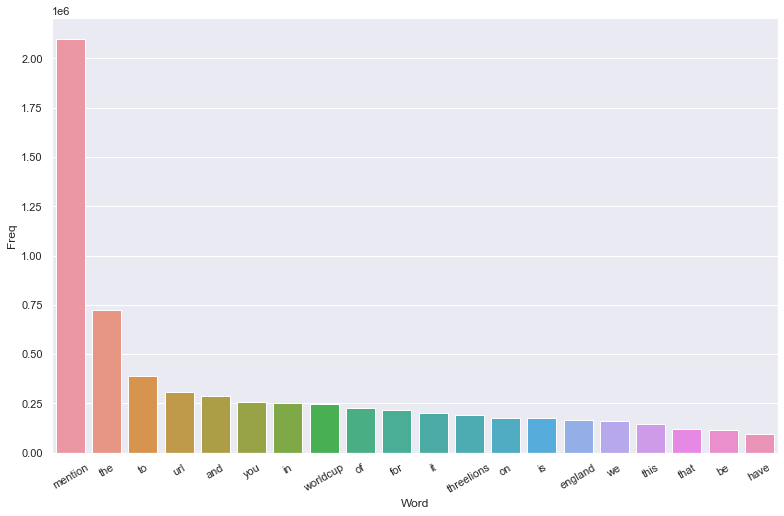

```python
import seaborn as sns

sns.set(rc={'figure.figsize':(13,8)})
g = sns.barplot(x="Word", y= "Freq", data=top_df)
g.set_xticklabels(g.get_xticklabels(), rotation = 30)
```

Como podemos observar, la mayoría de palabras con un alto grado de repetición no nos aportan valor, por lo que tenemos que seguir trabajando nuestro texto.

En el siguiente paso, la **tokenización** trataremos de solucionar este problema, entre otros.

# Extracción de features (tokenización)

```python
from nltk.tokenize import TweetTokenizer
#from nltk.tokenize import word_tokenize#, RegexpTokenizer
from nltk.corpus import stopwords
#from autocorrect import Speller
#from nltk.stem.porter import PorterStemmer
from nltk.stem.wordnet import WordNetLemmatizer
```

Con el fin de eliminar la anteriormente citadas palabras que no aportan valor a nuestro texto, utilizaremos el concepto de **stop words**.

Tras la realización de algunas pruebas, se ha optado por un listado *customizado* en el que no se eliminan las palabras con una posible connotación negativa, además de incluirse algunas como MENTION o URL añadidas por nuestro preprocesado de la etapa anterior.

```python
custom_stopwords = ['a', 'about', 'above', 'after', 'again', 'ain', 'all', 'am', 'an',
             'and','any','are', 'as', 'at', 'be', 'because', 'been', 'before',
             'being', 'below', 'between','both', 'by', 'can', 'd', 'did', 'do',
             'does', 'doing', 'down', 'during', 'each','few', 'for', 'from',
             'further', 'had', 'has', 'have', 'having', 'he', 'her', 'here',
             'hers', 'herself', 'him', 'himself', 'his', 'how', 'i', 'if', 'in',
             'into','is', 'it', 'its', 'itself', 'just', 'll', 'm', 'ma',
             'me', 'MENTION', 'more', 'most', 'my', 'myself', 'now', 'o', 'of', 'on', 'once',
             'only', 'or', 'other', 'our', 'ours','ourselves', 'out', 'own', 're',
             's', 'same', 'she', "shes", 'should', "shouldve",'so', 'some', 'such',
             't', 'than', 'that', "thatll", 'the', 'their', 'theirs', 'them',
             'themselves', 'then', 'there', 'these', 'they', 'this', 'those',
             'through', 'to', 'too','under', 'until', 'up', 'URL', 've', 'very', 'was',
             'we', 'were', 'what', 'when', 'where','which','while', 'who', 'whom',
             'why', 'will', 'with', 'won', 'y', 'you', "youd","youll", "youre",
             "youve", 'your', 'yours', 'yourself', 'yourselves']
```

En las siguientes líneas, se define una función en la que se realiza:

- Una tokenización a través del TweetTokenizer de nltk
- Borrado de las *stop words*
- Lemmatización de los tokens

Se ha optado por una Lemmatización, tras haber probado con varias versiones de Stemmer e incluso con corrección de errores (Speller) por coste computacional y aparentemente unos resultados más sencillos de interpretar.

```python
tknzr = TweetTokenizer()

def tokenize_text(text):
    try:
        #print(text,'\n')

        # Texto tokenizado
        text = tknzr.tokenize(text)
        text = [t for t in text if len(t) > 1]  # Remove short tokens
        #text = ["" if t.isdigit() else t for t in text]  # Remove digits

        # Borrado de stopwords
        text = [word for word in text if not word in custom_stopwords]

        # Lematización
        lem = WordNetLemmatizer()
        text = [lem.lemmatize(word) for word in text if not word in custom_stopwords]

        return text

    except Exception:
        print("Error:\n", text)
```

Del mismo modo que en la etapa anterior, realizamos una visualización de resultados de los 100 primeros tweets, procesamos todos los valores, y guardamos en data.

```python
for tweet in tqdm(data['clean_text'][:100]):
    print(tweet,'\n')
    result = tokenize_text(tweet)
    print(result, '\n\n')
```

```
 MENTION MENTION MENTION MENTION looking for web developer contact me or URL
```

```
['looking', 'web', 'developer', 'contact']


i just bought a new socceroos jersey at i first thought it was a bit excessive but i figure as i can wear it for the games we’ll be in then its only a game great value #worldcuprussia #aus #socceroos

['bought', 'new', 'socceroos', 'jersey', 'first', 'thought', 'bit', 'excessive', 'but', 'figure', 'wear', 'game', 'game', 'great', 'value', '#worldcuprussia', '#aus', '#socceroos']


 MENTION MENTION you look good man i'd appreciate if i got your jersey here in africa

['look', 'good', 'man', "i'd", 'appreciate', 'got', 'jersey', 'africa']


 MENTION MENTION henderson should be left at home let alone be captain at the world cup

['henderson', 'left', 'home', 'let', 'alone', 'captain', 'world', 'cup']


harry maguire absolutely towering in second half and extra time #threelions #comeonengland

['harry', 'maguire', 'absolutely', 'towering', 'second', 'half', 'extra', 'time', '#threelions', '#comeonengland']


 MENTION ya and we’re getting dominated smh we better get it together i don’t care how tired they are this is the #worldcup go dig deep and step up #coleng

['ya', 'getting', 'dominated', 'smh', 'better', 'get', 'together', 'don', 'care', 'tired', '#worldcup', 'go', 'dig', 'deep', 'step', '#coleng']


back in england what a trip that was feels like a dream i assumed we would lose to germany in the quarters on penalties thank goodness that didn’t happen cheers MENTION

['back', 'england', 'trip', 'feel', 'like', 'dream', 'assumed', 'would', 'lose', 'germany', 'quarter', 'penalty', 'thank', 'goodness', 'didn', 'happen', 'cheer']


 MENTION as much as i don't rate henderson he is an england player until we are out so stop this shit oh and i am a solid blue #comeonengland #coyb

['much', "don't", 'rate', 'henderson', 'england', 'player', 'stop', 'shit', 'oh', 'solid', 'blue', '#comeonengland', '#coyb']


come on MENTION you can do it today #eng #threelions

```

[output cut: 441 more lines]

```


 MENTION MENTION MENTION MENTION MENTION MENTION MENTION MENTION MENTION MENTION unfortunately they haven't saw one of them claiming the henderson has been player of the tournament

['unfortunately', "haven't", 'saw', 'one', 'claiming', 'henderson', 'player', 'tournament']


if MENTION scored goals vs #spain then he will have no problem doing the same vs #morocco right MENTION MENTION #pormar #por #mar #worldcup

['scored', 'goal', 'v', '#spain', 'no', 'problem', 'v', '#morocco', 'right', '#pormar', '#por', '#mar', '#worldcup']


 MENTION MENTION MENTION boring they called iheanacho uncle kel u can't can't say lazy ozil or egbon khedira

['boring', 'called', 'iheanacho', 'uncle', 'kel', "can't", "can't", 'say', 'lazy', 'ozil', 'egbon', 'khedira']
```

```python
tokenized_tweets = data['clean_text'].progress_apply(tokenize_text)
```

```python
data['tokenized_text'] = tokenized_tweets
```

## Creación del vocabulario y vectorización de palabras

```python
from gensim.models import Word2Vec
from sklearn.decomposition import PCA
from matplotlib import pyplot
from collections import Counter
```

A través del objeto Counter, hacemos un recuento de los tokens para visualizar algunos de los elementos más repetidos

```python
vocab_clean = Counter()

for token in tokenized_tweets:
    vocab_clean.update(token)

vocab_clean.most_common(20)
```

```
[('#worldcup', 241172),
 ('#threelions', 192322),
 ('england', 118001),
 ('team', 91113),
 ('world', 89241),
 ('but', 87820),
 ('#eng', 82641),
 ('cup', 78428),
 ('not', 76127),
 ('game', 74687),
 ('win', 66329),
 ('get', 62912),
 ('come', 60848),
 ('home', 59210),
 ('#comeonengland', 57671),
 ('proud', 52716),
 ('#itscominghome', 52397),
 ('time', 52359),
 ('go', 52325),
 ('good', 51506)]
```

Podemos ver, como a diferencia de la etapa anterior a la tokenización, estas palabras tienen una mayor relevancia para nuestro problema

Posteriormente, se ha optado por la utilización de **Word2Vec** como representación vectorial de nuestros tokens, para posteriormente ser el tipo de dato con el que alimentar nuestros modelos de clasificación. Esta decisión se ha tomado dada la extensión en su uso de esta red de 2 capas, y siendo así un punto de partida sobre el que continuar nuestro análisis en función de los resultados obtenidos.

Para ello, nos apoyamos en *multiprocessing* para utilizar los *cores* disponibles.

```python
import multiprocessing
cores = multiprocessing.cpu_count()
cores
```

```
4
```

```python
from gensim.models import phrases
bigrams = phrases.Phrases(tokenized_tweets)

w2v_model = Word2Vec(bigrams[tokenized_tweets],
                    min_count=0.2,
                    size=100,
                    workers=cores
                    )
```

Una vez construido el modelo, podemos ver la estructura de este tipo de vectores con un ejemplo.

```python
w2v_model["england"]
```

```
array([ 3.2759697 , -0.8643846 , -0.66278696,  1.4729555 ,  0.4203503 ,
        0.8793103 ,  2.133503  ,  0.7913275 ,  1.4425128 ,  2.0074453 ,
        0.05508431, -2.733225  ,  1.3340394 ,  0.9714867 , -0.54361737,
        2.280251  ,  0.73625207,  0.3396604 ,  0.14355563, -1.2884672 ,
       -1.7491517 , -1.1229235 ,  0.09610964,  0.8816658 ,  0.10272564,
       -1.6163019 ,  3.6141515 ,  1.4878478 , -0.83411235,  2.414345  ,
        3.0354114 ,  1.28893   ,  1.0030501 , -1.1050992 ,  0.78825206,
        2.8594377 ,  2.3131216 , -0.34239852, -0.5982081 ,  0.21799156,
       -0.64367175, -1.2460543 ,  1.7813444 , -1.1557703 ,  0.2982331 ,
        1.4060545 , -1.6376898 , -1.418234  ,  0.5342644 , -0.8830999 ,
       -1.2105589 ,  2.0904493 ,  0.8162382 ,  0.13600792, -0.66891444,
       -0.87894934, -0.02724316,  2.934777  , -0.768293  ,  1.2154363 ,
        2.5139942 , -0.89612776, -0.20019862,  0.34706184,  1.198316  ,
       -0.5387274 , -2.302708  , -0.15426794,  0.7611163 ,  0.7625003 ,
        0.37152025, -1.241333  , -1.0432446 , -0.18546368, -1.2506928 ,
       -0.70404047, -0.37874365, -1.3129193 ,  1.0891999 , -1.5020633 ,
        1.3450809 ,  0.3087983 , -3.0845225 , -4.115017  , -2.1484332 ,
        0.56640375, -1.8557289 ,  0.7074071 ,  1.2801812 , -1.2466819 ,
       -0.87118584,  0.7672231 ,  1.4124434 ,  0.2149094 , -0.5659926 ,
        1.72024   ,  1.7561585 ,  1.2534741 ,  0.08033075,  1.7259253 ],
      dtype=float32)
```

También podemos observar las palabras similares a una dada, o el grado de similitud entre dos seleccionadas, con el objetivo de ver como de bien está funcionando nuestro modelo.

```python
w2v_model.wv.most_similar("england", topn=10)
```

```
[("england's", 0.6775725483894348),
 ('three_lion', 0.6060900092124939),
 ('english', 0.5977537631988525),
 ('lad', 0.5817394256591797),
 ('eng', 0.5732208490371704),
 ('#threelions', 0.563014030456543),
 ('scotland', 0.5628576874732971),
 ('#eng', 0.5538583397865295),
 ('tunisia', 0.5491582155227661),
 ('decent', 0.5410511493682861)]
```

```python
w2v_model.similarity('#threelions', 'england')
```

```
0.5630141
```

## Composición por frase de los vectores de palabra

Dado que nuestro análisis de sentimiento debe hacerse a nivel de tweet, no de palabra, se ha optado por la composición de las palabras que aparecen en los tweets de dos formas distintas utilizando los vectores ofrecidos por Word2Vec.

1. Realizando la media de los vectores (sumVectorsMean)
2. Realizando un sumatorio de los valores (sumVectors)

```python
import numpy as np
```

```python
def sumVectorsMean(tokens):
    result = np.zeros(100)
    values = [w2v_model[token] for token in tokens if token in w2v_model.wv.vocab.keys()]
    if len(values) > 0:
        result = np.mean(result + values, axis=0)

    #print(type(model_vector))
    return list(result)
```

```python
def sumVectors(tokens):
    result = np.zeros(100)

    for token in tokens:
        if token in w2v_model.wv.vocab.keys():
            result = result + w2v_model[token]
    #print(type(result))

    return list(result)
```

Cargamos ambas opciones generadas en nuestro dataset

```python
data['vectorsMean'] = data['tokenized_text'].progress_apply(sumVectorsMean)
```

```
  values = [w2v_model[token] for token in tokens if token in w2v_model.wv.vocab.keys()]
```

```python
data['vectors'] = data['tokenized_text'].progress_apply(sumVectors)
```

```
  result = result + w2v_model[token]
```

# Split data

```python
from sklearn.model_selection import train_test_split
```

```python
XMean = data['vectorsMean'].copy()
XSum = data['vectors'].copy()

y = data['sentiment'].copy()
```

Traducimos las distintas etiquetas de sentimiento a valores numéricos

```python
class_label = {
    "POSITIVE" : 0,
    "NEGATIVE" : 1,
    "NEUTRAL" : 2,
    "MIXED" : 3
}
y.replace(class_label, inplace = True)
```

```python
XMean_train, XMean_test, yMean_train, yMean_test = train_test_split(XMean, y)
XSum_train, XSum_test, ySum_train, ySum_test = train_test_split(XSum, y)
```

```python
# Train
XMean_train = XMean_train.values.tolist()
yMean_train = yMean_train.tolist()

XSum_train = XSum_train.values.tolist()
ySum_train = ySum_train.tolist()

# Test
XMean_test = XMean_test.values.tolist()
yMean_test = yMean_test.tolist()

XSum_test = XSum_test.values.tolist()
ySum_test = ySum_test.tolist()
```

# Modelado

```python
from sklearn.linear_model import LogisticRegression
from sklearn.tree import DecisionTreeClassifier
from sklearn.ensemble import RandomForestClassifier
from sklearn.neighbors import KNeighborsClassifier
from sklearn.naive_bayes import GaussianNB, MultinomialNB
from sklearn.svm import SVC
```

```python
num_trees = 10
seed      = 2

models = []
models.append(('NB', GaussianNB()))
models.append(('CART', DecisionTreeClassifier(random_state=seed)))
models.append(('RF', RandomForestClassifier(n_estimators=num_trees, random_state=seed)))
```

```python
import time
```

```python
from sklearn.metrics import confusion_matrix, classification_report
```

```python
from matplotlib import pyplot as plt

def plot_confusion_matrix(y_test, y_pred):
    #plt.figure(dpi=600)
    mat = confusion_matrix(y_test, y_pred)
    sns.heatmap(mat.T, annot = True, fmt='d', cbar=False)

    plt.title('MATRIZ DE CONFUSIÓN')
    #plt.legend(class_label)
    plt.xlabel('Valor real')
    plt.ylabel('Predicción')
    plt.show()
```

```python
def test_models(models, X_train, X_test, y_train, y_test):
    for name, model in models:
        start_time = time.time()
        model.fit(X_train, y_train)
        msg = "%s: %f " % (name, model.score(X_test, y_test))
        print(msg)
        print("Time to fit (seg): " + str(round(time.time() - start_time)))

        y_pred = model.predict(X_test)
        print(classification_report(y_test, y_pred, target_names = class_label.keys()))
        plot_confusion_matrix(y_test, y_pred)
```

```
MEAN VECTORS
NB: 0.559313
Time to fit (seg): 21
              precision    recall  f1-score   support

    POSITIVE       0.57      0.45      0.50     56866
    NEGATIVE       0.13      0.58      0.21     10658
     NEUTRAL       0.86      0.59      0.70    166646
       MIXED       0.04      0.65      0.07      1623

    accuracy                           0.56    235793
   macro avg       0.40      0.57      0.37    235793
weighted avg       0.75      0.56      0.63    235793
```

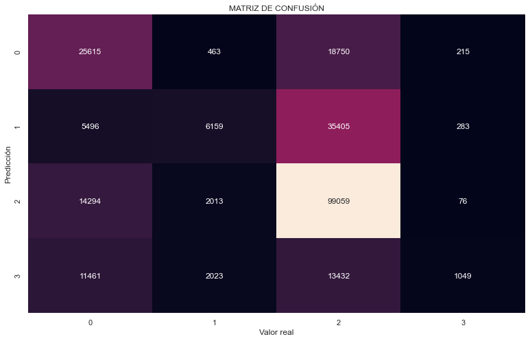

```
CART: 0.712888
Time to fit (seg): 241
              precision    recall  f1-score   support

    POSITIVE       0.55      0.56      0.55     56866
    NEGATIVE       0.21      0.23      0.22     10658
     NEUTRAL       0.82      0.80      0.81    166646
       MIXED       0.07      0.09      0.08      1623

    accuracy                           0.71    235793
   macro avg       0.41      0.42      0.42    235793
weighted avg       0.72      0.71      0.72    235793
```

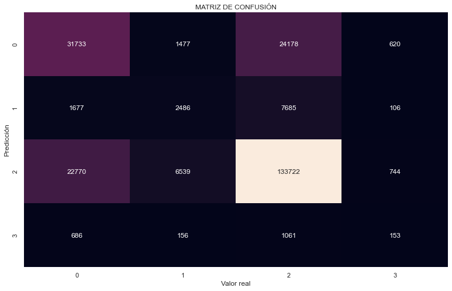

```
RF: 0.795838
Time to fit (seg): 199
              precision    recall  f1-score   support

    POSITIVE       0.70      0.59      0.64     56866
    NEGATIVE       0.61      0.13      0.21     10658
     NEUTRAL       0.82      0.92      0.87    166646
       MIXED       0.89      0.05      0.09      1623

    accuracy                           0.80    235793
   macro avg       0.75      0.42      0.45    235793
weighted avg       0.78      0.80      0.78    235793
```

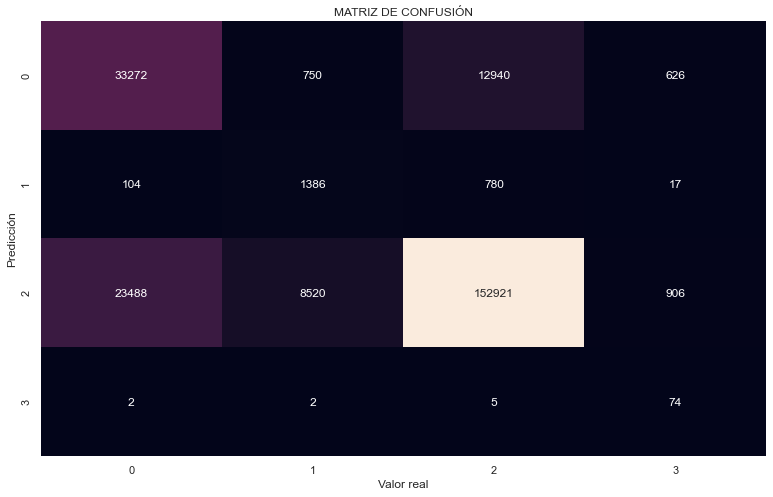

```
SUM VECTORS
NB: 0.620044
Time to fit (seg): 26
              precision    recall  f1-score   support

    POSITIVE       0.58      0.26      0.35     56765
    NEGATIVE       0.16      0.21      0.18     10613
     NEUTRAL       0.79      0.77      0.78    166813
       MIXED       0.02      0.46      0.04      1602

    accuracy                           0.62    235793
   macro avg       0.39      0.42      0.34    235793
weighted avg       0.70      0.62      0.64    235793
```

[figure not shown]

```
CART: 0.721527
Time to fit (seg): 270
              precision    recall  f1-score   support

    POSITIVE       0.56      0.56      0.56     56765
    NEGATIVE       0.22      0.23      0.23     10613
     NEUTRAL       0.82      0.81      0.82    166813
       MIXED       0.10      0.12      0.11      1602

    accuracy                           0.72    235793
   macro avg       0.42      0.43      0.43    235793
weighted avg       0.73      0.72      0.72    235793
```

[figure not shown]

```
RF: 0.799489
Time to fit (seg): 191
              precision    recall  f1-score   support

    POSITIVE       0.70      0.60      0.64     56765
    NEGATIVE       0.60      0.14      0.23     10613
     NEUTRAL       0.83      0.92      0.87    166813
       MIXED       0.91      0.06      0.11      1602

    accuracy                           0.80    235793
   macro avg       0.76      0.43      0.46    235793
weighted avg       0.79      0.80      0.78    235793
```

[figure not shown]

```python
# MEAN VECTORS
print("MEAN VECTORS")
test_models(models, XMean_train, XMean_test, yMean_train, yMean_test)

# SUM VECTORES
print("\n\nSUM VECTORS")
test_models(models, XSum_train, XSum_test, ySum_train, ySum_test)
```

# Primeras conclusiones

En esta primera iteración sobre nuestro problema, además de que los resultados no son buenos, podemos concluir una serie de puntos importantes:

- El tiempo de procesamiento para ciertas etapas es excesivo.
- Necesidad de revisión de la estructura de los datos de entrenamient (vectores Word2Vec).
- Estudio y ajuste de la selección de datos para entrenar y modelos a utilizar.

Varios de los puntos anteriores como el tiempo de procesamiento o la selección de los datos, dependen en gran medida de la magnitud del dataset. Para ello, podemos realizar algunas operaciones:

Eliminar duplicados:

```python
len(data)
```

```
943169
```

```python
data.drop_duplicates(subset=['tweet_text'], inplace = True)
```

```python
len(data)
```

```
860931
```

Haremos también uso de la columna **sentiment_score**, la cual nos permitirá seleccionar los tweets con un mayor valor representativo para cada tipo.

En este punto, inicialmente se ha optado por eliminar los valores sentiment=MIXED, reduciendo así ligeramente la complejidad del problema.

```python
def split_sentiment(string):
    #print(string)
    string_list = string.split(',')
    #print(string_list)

    for s in string_list:
        if 'Positive' in s:
            #positive = float(s.replace('"Positive":',''))
            positive = float(re.sub('[{}]','' ,s.split(':')[1]))
        if 'Negative' in s:
            negative = float(re.sub('[{}]','' ,s.split(':')[1]))
        if 'Neutral' in s:
            neutral = float(re.sub('[{}]','' ,s.split(':')[1]))
    return positive, negative, neutral
```

```python
data['Positive'], data['Negative'], data['Neutral'] = zip(*data['sentiment_score'].progress_apply(split_sentiment))
```

```python
selected_data = data.copy() #hacemos una nueva copia para trabajar los datos
```

```python
positives = selected_data[selected_data['Positive'] > 0.75].copy()
negatives = selected_data[selected_data['Negative'] > 0.75].copy()
neutrals = selected_data[selected_data['Neutral'] > 0.95].copy()

selected_data = pd.concat([positives, negatives, neutrals])
```

### Balancear los datos:

```python
selected_data.sentiment.value_counts()
```

```
NEUTRAL     179309
POSITIVE    116742
NEGATIVE     12220
Name: sentiment, dtype: int64
```

```python
selected_data.sentiment.value_counts(normalize=True)
```

```
NEUTRAL     0.581660
POSITIVE    0.378699
NEGATIVE    0.039640
Name: sentiment, dtype: float64
```

```python
from sklearn.utils import resample
```

```python
positives_downsampled = resample(positives, replace = False, n_samples = 12220)
neutrals_downsampled = resample(neutrals, replace = False, n_samples = 12220)

selected_data = pd.concat([positives_downsampled, negatives, neutrals_downsampled])
selected_data.sentiment.value_counts()
```

```
NEUTRAL     12220
NEGATIVE    12220
POSITIVE    12220
Name: sentiment, dtype: int64
```

Repetimos las etapas de preparación del dataset y modelado con esta nueva selección

```python
XMean = selected_data['vectorsMean'].copy()
XSum = selected_data['vectors'].copy()

y = selected_data['sentiment'].copy()

class_label = {
    "POSITIVE" : 0,
    "NEGATIVE" : 1,
    "NEUTRAL" : 2
}
y.replace(class_label, inplace = True)
```

```python
XMean_train, XMean_test, yMean_train, yMean_test = train_test_split(XMean, y)
XSum_train, XSum_test, ySum_train, ySum_test = train_test_split(XSum, y)

# Train
XMean_train = XMean_train.values.tolist()
yMean_train = yMean_train.tolist()
XSum_train = XSum_train.values.tolist()
ySum_train = ySum_train.tolist()

# Test
XMean_test = XMean_test.values.tolist()
yMean_test = yMean_test.tolist()
XSum_test = XSum_test.values.tolist()
ySum_test = ySum_test.tolist()
```

Como hemos reducido el coste computacional, añadimos otros dos modelos en nuestro listado para el estudio de resultados:

- KNN
- SVM

```python
models = []
models.append(('NB', GaussianNB()))
models.append(('CART', DecisionTreeClassifier(random_state=seed)))
models.append(('RF', RandomForestClassifier(n_estimators=num_trees, random_state=seed)))
models.append(('KNN', KNeighborsClassifier()))
models.append(('SVM', SVC(random_state=seed)))
```

```
MEAN VECTORS
NB: 0.753301
Time to fit (seg): 1
              precision    recall  f1-score   support

    POSITIVE       0.84      0.71      0.77      3011
    NEGATIVE       0.70      0.84      0.76      3013
     NEUTRAL       0.74      0.72      0.73      3141

    accuracy                           0.75      9165
   macro avg       0.76      0.75      0.75      9165
weighted avg       0.76      0.75      0.75      9165
```

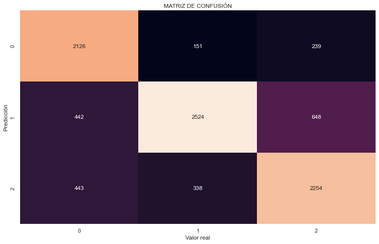

```
CART: 0.694381
Time to fit (seg): 6
              precision    recall  f1-score   support

    POSITIVE       0.70      0.73      0.71      3011
    NEGATIVE       0.69      0.70      0.70      3013
     NEUTRAL       0.69      0.66      0.67      3141

    accuracy                           0.69      9165
   macro avg       0.69      0.69      0.69      9165
weighted avg       0.69      0.69      0.69      9165
```

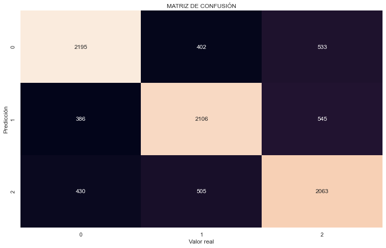

```
RF: 0.781015
Time to fit (seg): 4
              precision    recall  f1-score   support

    POSITIVE       0.78      0.81      0.80      3011
    NEGATIVE       0.77      0.81      0.79      3013
     NEUTRAL       0.79      0.73      0.76      3141

    accuracy                           0.78      9165
   macro avg       0.78      0.78      0.78      9165
weighted avg       0.78      0.78      0.78      9165
```

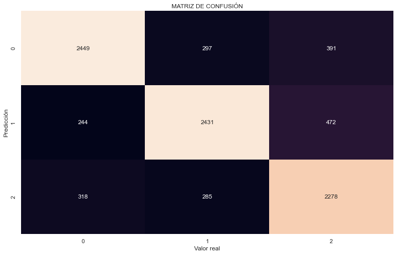

```
KNN: 0.789962
Time to fit (seg): 99
              precision    recall  f1-score   support

    POSITIVE       0.80      0.83      0.82      3011
    NEGATIVE       0.73      0.89      0.80      3013
     NEUTRAL       0.86      0.65      0.74      3141

    accuracy                           0.79      9165
   macro avg       0.80      0.79      0.79      9165
weighted avg       0.80      0.79      0.79      9165
```

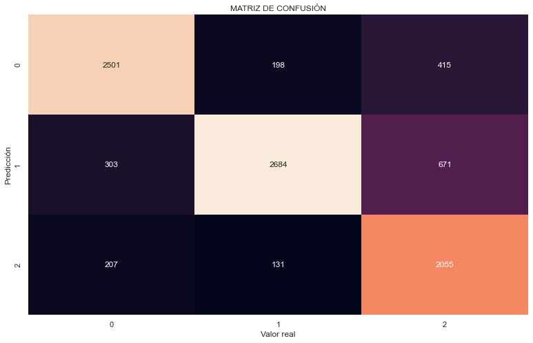

```
SVM: 0.890453
Time to fit (seg): 85
              precision    recall  f1-score   support

    POSITIVE       0.93      0.89      0.91      3011
    NEGATIVE       0.87      0.90      0.89      3013
     NEUTRAL       0.88      0.88      0.88      3141

    accuracy                           0.89      9165
   macro avg       0.89      0.89      0.89      9165
weighted avg       0.89      0.89      0.89      9165
```

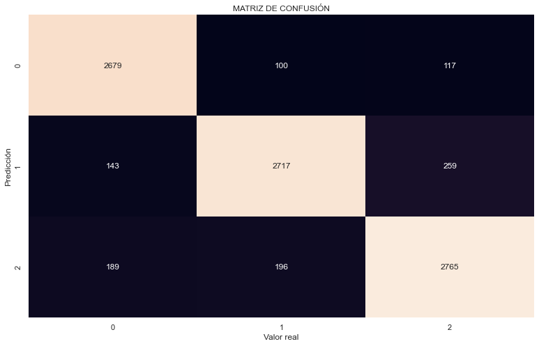

```
SUM VECTORS
NB: 0.649973
Time to fit (seg): 1
              precision    recall  f1-score   support

    POSITIVE       0.83      0.54      0.65      2995
    NEGATIVE       0.76      0.57      0.65      3027
     NEUTRAL       0.53      0.83      0.65      3143

    accuracy                           0.65      9165
   macro avg       0.71      0.65      0.65      9165
weighted avg       0.70      0.65      0.65      9165
```

[figure not shown]

```
CART: 0.691326
Time to fit (seg): 6
              precision    recall  f1-score   support

    POSITIVE       0.71      0.71      0.71      2995
    NEGATIVE       0.69      0.69      0.69      3027
     NEUTRAL       0.68      0.68      0.68      3143

    accuracy                           0.69      9165
   macro avg       0.69      0.69      0.69      9165
weighted avg       0.69      0.69      0.69      9165
```

[figure not shown]

```
RF: 0.786798
Time to fit (seg): 3
              precision    recall  f1-score   support

    POSITIVE       0.79      0.82      0.80      2995
    NEGATIVE       0.77      0.80      0.79      3027
     NEUTRAL       0.79      0.75      0.77      3143

    accuracy                           0.79      9165
   macro avg       0.79      0.79      0.79      9165
weighted avg       0.79      0.79      0.79      9165
```

[figure not shown]

```
KNN: 0.803164
Time to fit (seg): 80
              precision    recall  f1-score   support

    POSITIVE       0.84      0.81      0.82      2995
    NEGATIVE       0.77      0.85      0.80      3027
     NEUTRAL       0.81      0.76      0.78      3143

    accuracy                           0.80      9165
   macro avg       0.80      0.80      0.80      9165
weighted avg       0.80      0.80      0.80      9165
```

[figure not shown]

```
SVM: 0.877905
Time to fit (seg): 89
              precision    recall  f1-score   support

    POSITIVE       0.91      0.88      0.90      2995
    NEGATIVE       0.86      0.88      0.87      3027
     NEUTRAL       0.86      0.87      0.87      3143

    accuracy                           0.88      9165
   macro avg       0.88      0.88      0.88      9165
weighted avg       0.88      0.88      0.88      9165
```

[figure not shown]

```python
# MEAN VECTORS
print("MEAN VECTORS")
test_models(models, XMean_train, XMean_test, yMean_train, yMean_test)

# SUM VECTORES
print("\n\nSUM VECTORS")
test_models(models, XSum_train, XSum_test, ySum_train, ySum_test)
```

Podemos observar, como nuestros resultados han mejorado ligeramente. Vamos a intentar simplificar aún más nuestro problema, yendo a un análisis más sencillo y puede que también más útil.

La detección de **positivos y negativos**.

```python
selected_data = pd.concat([positives_downsampled, negatives])
selected_data.sentiment.value_counts()
```

```
NEGATIVE    12220
POSITIVE    12220
Name: sentiment, dtype: int64
```

```python
XMean = selected_data['vectorsMean'].copy()
XSum = selected_data['vectors'].copy()
y = selected_data['sentiment'].copy()

class_label = {
    "POSITIVE" : 0,
    "NEGATIVE" : 1
}
y.replace(class_label, inplace = True)

XMean_train, XMean_test, yMean_train, yMean_test = train_test_split(XMean, y)
XSum_train, XSum_test, ySum_train, ySum_test = train_test_split(XSum, y)

# Train
XMean_train = XMean_train.values.tolist()
yMean_train = yMean_train.tolist()
XSum_train = XSum_train.values.tolist()
ySum_train = ySum_train.tolist()

# Test
XMean_test = XMean_test.values.tolist()
yMean_test = yMean_test.tolist()
XSum_test = XSum_test.values.tolist()
ySum_test = ySum_test.tolist()
```

```
MEAN VECTORS
NB: 0.876432
Time to fit (seg): 0
              precision    recall  f1-score   support

    POSITIVE       0.90      0.84      0.87      3066
    NEGATIVE       0.85      0.91      0.88      3044

    accuracy                           0.88      6110
   macro avg       0.88      0.88      0.88      6110
weighted avg       0.88      0.88      0.88      6110
```

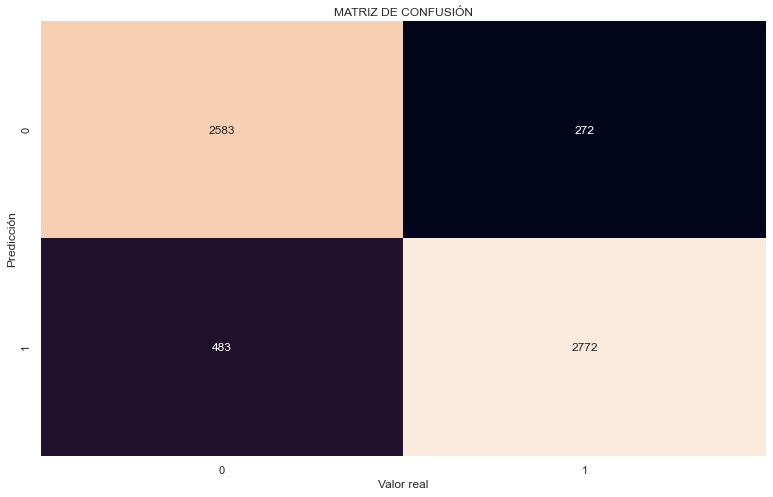

```
CART: 0.833879
Time to fit (seg): 4
              precision    recall  f1-score   support

    POSITIVE       0.84      0.83      0.83      3066
    NEGATIVE       0.83      0.83      0.83      3044

    accuracy                           0.83      6110
   macro avg       0.83      0.83      0.83      6110
weighted avg       0.83      0.83      0.83      6110
```

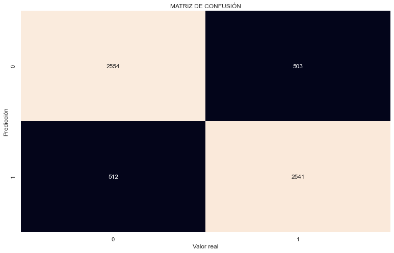

```
RF: 0.892471
Time to fit (seg): 2
              precision    recall  f1-score   support

    POSITIVE       0.88      0.92      0.90      3066
    NEGATIVE       0.91      0.87      0.89      3044

    accuracy                           0.89      6110
   macro avg       0.89      0.89      0.89      6110
weighted avg       0.89      0.89      0.89      6110
```

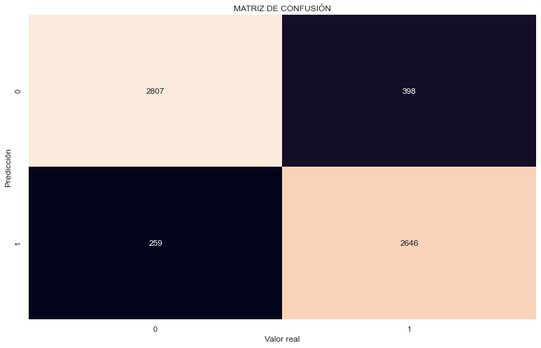

```
KNN: 0.903273
Time to fit (seg): 47
              precision    recall  f1-score   support

    POSITIVE       0.93      0.87      0.90      3066
    NEGATIVE       0.88      0.93      0.91      3044

    accuracy                           0.90      6110
   macro avg       0.90      0.90      0.90      6110
weighted avg       0.90      0.90      0.90      6110
```

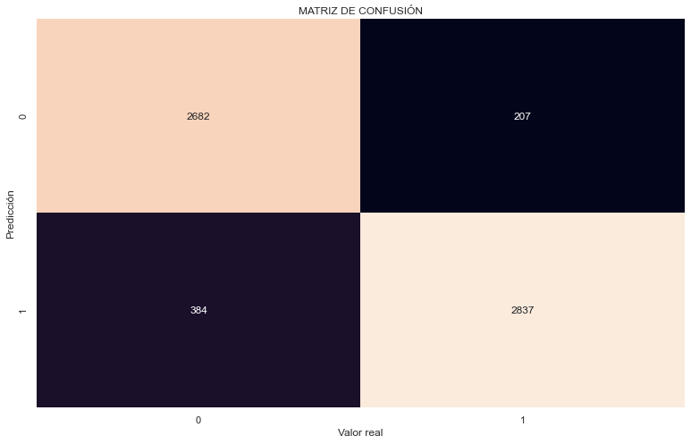

```
SVM: 0.945827
Time to fit (seg): 20
              precision    recall  f1-score   support

    POSITIVE       0.95      0.94      0.95      3066
    NEGATIVE       0.94      0.95      0.95      3044

    accuracy                           0.95      6110
   macro avg       0.95      0.95      0.95      6110
weighted avg       0.95      0.95      0.95      6110
```

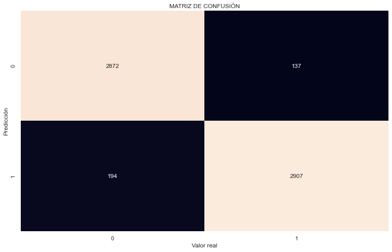

```
SUM VECTORS
NB: 0.893781
Time to fit (seg): 0
              precision    recall  f1-score   support

    POSITIVE       0.92      0.86      0.89      3077
    NEGATIVE       0.87      0.93      0.90      3033

    accuracy                           0.89      6110
   macro avg       0.90      0.89      0.89      6110
weighted avg       0.90      0.89      0.89      6110
```

[figure not shown]

```
CART: 0.828969
Time to fit (seg): 4
              precision    recall  f1-score   support

    POSITIVE       0.84      0.82      0.83      3077
    NEGATIVE       0.82      0.84      0.83      3033

    accuracy                           0.83      6110
   macro avg       0.83      0.83      0.83      6110
weighted avg       0.83      0.83      0.83      6110
```

[figure not shown]

```
RF: 0.885434
Time to fit (seg): 2
              precision    recall  f1-score   support

    POSITIVE       0.88      0.90      0.89      3077
    NEGATIVE       0.90      0.87      0.88      3033

    accuracy                           0.89      6110
   macro avg       0.89      0.89      0.89      6110
weighted avg       0.89      0.89      0.89      6110
```

[figure not shown]

```
KNN: 0.897709
Time to fit (seg): 40
              precision    recall  f1-score   support

    POSITIVE       0.93      0.86      0.89      3077
    NEGATIVE       0.87      0.93      0.90      3033

    accuracy                           0.90      6110
   macro avg       0.90      0.90      0.90      6110
weighted avg       0.90      0.90      0.90      6110
```

[figure not shown]

```
SVM: 0.945336
Time to fit (seg): 21
              precision    recall  f1-score   support

    POSITIVE       0.95      0.94      0.95      3077
    NEGATIVE       0.94      0.96      0.95      3033

    accuracy                           0.95      6110
   macro avg       0.95      0.95      0.95      6110
weighted avg       0.95      0.95      0.95      6110
```

[figure not shown]

```python
# MEAN VECTORS
print("MEAN VECTORS")
test_models(models, XMean_train, XMean_test, yMean_train, yMean_test)

# SUM VECTORES
print("\n\nSUM VECTORS")
test_models(models, XSum_train, XSum_test, ySum_train, ySum_test)
```

Como podemos ver, la reducción del número de clase, suele facilitar las labores de clasificación.

También hemos podido ver en el clasificador de 3 y 2 clases, que determinados modelos presentan un tiempo de entrenamiento muy superior.

## BAG OF WORDS

Por último, vamos a probar otro método de representación de nuestros datos para el entrenamiento de los modelos, **Bag of Words.**

Optamos por esta representación simple y llanamente para realizar una comparación con los resultados obtenidos, teniendo muy presente que hay soluciones más complejas y quizá que mejores.

```python
selected_data = pd.concat([positives_downsampled, negatives])
selected_data.sentiment.value_counts()
```

```
NEGATIVE    12220
POSITIVE    12220
Name: sentiment, dtype: int64
```

```python
bow_vectorizer = CountVectorizer(max_df=0.90, max_features=10000, min_df = 2)
X = cv.fit_transform(selected_data['tokenized_text'].str.join(" "))
```

```python
y = selected_data['sentiment'].copy()

class_label = {
    "POSITIVE" : 0,
    "NEGATIVE" : 1
}
y.replace(class_label, inplace = True)
```

```python
X_train, X_test, y_train, y_test = train_test_split(X, y, test_size = 0.2)
```

```python
# Train
#X_train = X_train.values.tolist()
y_train = y_train.tolist()

# Test
#X_test = X_test.values.tolist()
y_test = y_test.tolist()
```

```python
models = []
models.append(('NB', MultinomialNB()))
models.append(('CART', DecisionTreeClassifier(random_state=seed)))
models.append(('RF', RandomForestClassifier(n_estimators=num_trees, random_state=seed)))
models.append(('KNN', KNeighborsClassifier()))
models.append(('SVM', SVC(random_state=seed)))
```

```
NB: 0.953151
Time to fit (seg): 0
              precision    recall  f1-score   support

    POSITIVE       0.97      0.93      0.95      2426
    NEGATIVE       0.94      0.97      0.95      2462

    accuracy                           0.95      4888
   macro avg       0.95      0.95      0.95      4888
weighted avg       0.95      0.95      0.95      4888
```

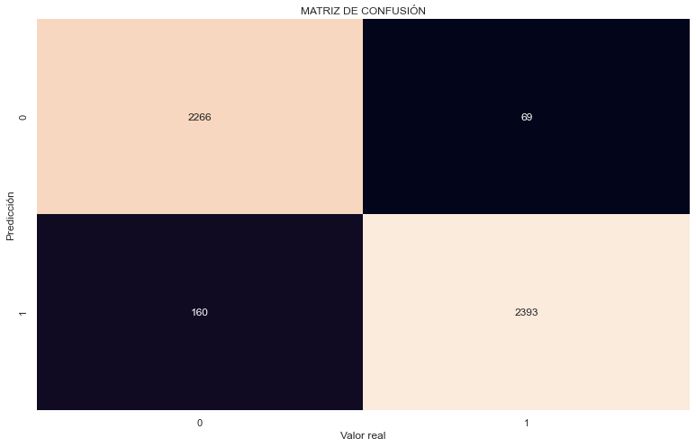

```
CART: 0.860884
Time to fit (seg): 3
              precision    recall  f1-score   support

    POSITIVE       0.84      0.89      0.86      2426
    NEGATIVE       0.88      0.84      0.86      2462

    accuracy                           0.86      4888
   macro avg       0.86      0.86      0.86      4888
weighted avg       0.86      0.86      0.86      4888
```

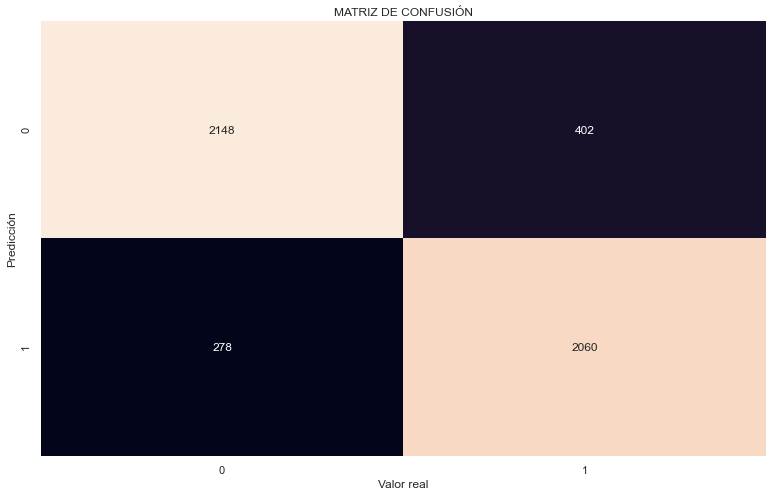

```
RF: 0.906097
Time to fit (seg): 2
              precision    recall  f1-score   support

    POSITIVE       0.87      0.95      0.91      2426
    NEGATIVE       0.94      0.87      0.90      2462

    accuracy                           0.91      4888
   macro avg       0.91      0.91      0.91      4888
weighted avg       0.91      0.91      0.91      4888
```

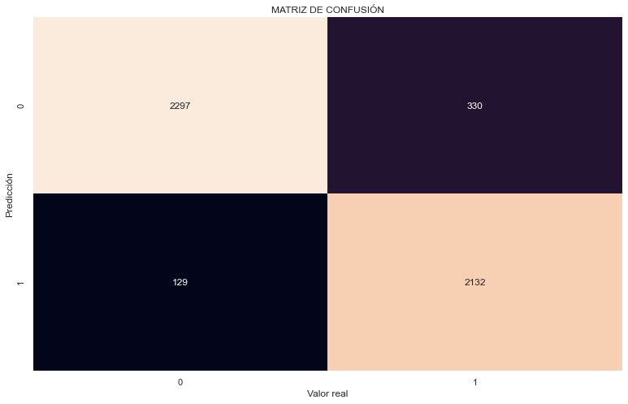

```
KNN: 0.769026
Time to fit (seg): 4
              precision    recall  f1-score   support

    POSITIVE       0.70      0.93      0.80      2426
    NEGATIVE       0.90      0.61      0.73      2462

    accuracy                           0.77      4888
   macro avg       0.80      0.77      0.76      4888
weighted avg       0.80      0.77      0.76      4888
```

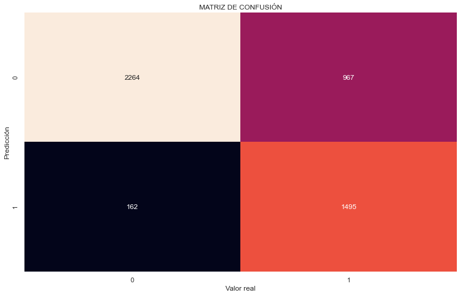

```
SVM: 0.961129
Time to fit (seg): 108
              precision    recall  f1-score   support

    POSITIVE       0.97      0.95      0.96      2426
    NEGATIVE       0.95      0.97      0.96      2462

    accuracy                           0.96      4888
   macro avg       0.96      0.96      0.96      4888
weighted avg       0.96      0.96      0.96      4888
```

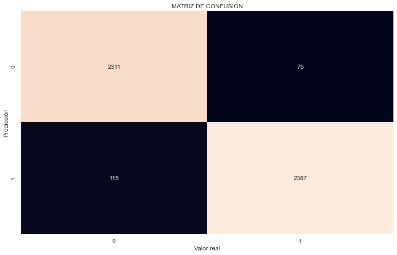

```python
test_models(models, X_train, X_test, y_train, y_test)
```

Por último comentar que me hubiera gustado probar TF-IDF, pero sobre todo una red neuronal, pero se me ha echado el tiempo encima.